# AppliedMLMidterm-Mousaw

## Intro

In this class, we have worked to understand both general principles of machine learning methods and specific details of particular machine learning techniques. For this project, you will apply what you have learned in this course to formulate and answer your own question, using ML. The midterm will be good practice for the final project, which will be similar.

**Important:** Be sure to include code and answers in the correct cells of the notebook. Otherwise we might miss your answers.

Please use this notebook to turn in your work.

Points: 20

You will be graded based on:

1. **Technical completeness**. *(12 points)*

Did you meet the technical requirements for the project? For instance, did you describe hyperparameter tuning and include plots, where necessary.

1. **Creativity and imagination**. *(3 points)*

Did you form an interesting and creative question, and explain why it is important to answer that question?

1. **Presentation**. *(5 points)*

Did you do a good job presenting your results? Would your notebook make sense to a person who was not familiar with your project? You should take time to write clearly, simplify your code and explain what you are doing in your notebook. Make sure your plots are well-labeled and appropriately scaled.

## Question

*Using this cell, please write a short, clear paragraph explaining what question you plan to answer in this notebook. Your question can be narrow (e.g. can we predict a dog's height from its weight) or broad (e.g. what features are important or unimportant in predicting the price of a house). Briefly describe why your question is important and how you plan to answer. Be sure to ask a question you can actually answer using machine learning techniques!*

I want to determine how accurately a wine's 'quality' (a subjective score given by humans) can be predicted based off its chemical composition.

## Data (writing)

*Using this cell, please write a short, clear paragraph explaining what data you will use to answer your question. You do not need to go gather custom datasets for this class, although you are welcome to do so. Just downloading data from Kaggle is fine, although we encourage you to think a little harder and more creatively when you do the project. There are many, many places to find interesting datasets online related to many topics like music, politics, sports, transportation, etc. Data gathering is one way to make your project more creative, but you are not expected or encouraged to take on a major data gathering effort. If applicable, describe how you plan to split between the training and test sets.*

From the UCI machine learning repository, I found a dataset that includes a chemical analysis of wines grown from a specific region in Italy. The columns are fixed acidity, volatile acidity, citric acid, residual sugar, chlorides, free sulfur dioxide, total sulfur dioxide, density, pH, sulphates, alcohol, and quality. I plan on splitting the data with quality being the label and all of the other columns being features. I am going to split training/testing data on a 70/30 split using a holdout method.

```python
## Code for data preprocessing

import numpy as np
import pandas as pd
import matplotlib.pyplot as plt
import sklearn
import seaborn as sb
%matplotlib inline
```

```python
#Load the dataset
red_wine_df = pd.read_csv('winequality-red.csv')

# separate out the features variables
red_features = red_wine_df.drop('quality', axis=1)

#create var for labels
red_labels = red_wine_df["quality"]

#Split data up 70|30 for train|test respectively
red_Y_train = red_labels[0:1119]
red_X_train = red_features[0:1119]

red_Y_test = red_labels[1119:]
red_X_test = red_features[1119:]

# inspect the dataset and take a look at the data
red_wine_df.head()
```

|  | fixed acidity | volatile acidity | citric acid | residual sugar | chlorides | free sulfur dioxide | total sulfur dioxide | density | pH | sulphates | alcohol | quality |
| --- | --- | --- | --- | --- | --- | --- | --- | --- | --- | --- | --- | --- |
| 0 | 7.4 | 0.70 | 0.00 | 1.9 | 0.076 | 11.0 | 34.0 | 0.9978 | 3.51 | 0.56 | 9.4 | 5 |
| 1 | 7.8 | 0.88 | 0.00 | 2.6 | 0.098 | 25.0 | 67.0 | 0.9968 | 3.20 | 0.68 | 9.8 | 5 |
| 2 | 7.8 | 0.76 | 0.04 | 2.3 | 0.092 | 15.0 | 54.0 | 0.9970 | 3.26 | 0.65 | 9.8 | 5 |
| 3 | 11.2 | 0.28 | 0.56 | 1.9 | 0.075 | 17.0 | 60.0 | 0.9980 | 3.16 | 0.58 | 9.8 | 6 |
| 4 | 7.4 | 0.70 | 0.00 | 1.9 | 0.076 | 11.0 | 34.0 | 0.9978 | 3.51 | 0.56 | 9.4 | 5 |

```python
#Inspect training and testing data

print("Test Data")
print("Red X test"+str(red_X_test.shape))
print("Red Y test"+str(red_Y_test.shape))
print()
print("Train Data")
print("Red X test"+str(red_X_train.shape))
print("Red Y test"+str(red_Y_train.shape))
```

```
Test Data
Red X test(480, 11)
Red Y test(480,)

Train Data
Red X test(1119, 11)
Red Y test(1119,)
```

## Model selection

*Using this cell, please write a short, clear paragraph explaining how you selected and tuned your model for the project. You must answer the following two questions in this cell (1) Why is your model an appropriate choice for your data? (2) What hyperparameters does your model have and how did you select them? (3) What features did you choose and why? You must engineer at least 1 feature*

I chose knn as the classifier for this dataset for a few reasons. I suspected that wines with similar characteristics would be rated as having a similar quality which is a 1-10 rating. If this was the case, knn would be an effective classifier due to clustering of wines with similar characteristics. I also liked that knn only has 1 hyperparameter, which is the value for k, or the number of neighbors. A reason not to chose knn for this dataset would be that there are 11 features, and knn can struggle with high dimensionality. I chose to go full steam ahead with knn anyway.

Initially, I am going to include all features without engineering any of them to see how knn performs on all features, just for fun.

```python
# import the classifier

#Run knn on training data for red wines,  then on testing data.
from sklearn.neighbors import KNeighborsClassifier
from sklearn import metrics
```

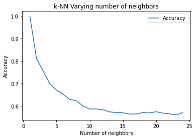

```python
#Setup arrays to store training and test accuracies
neighbors = np.arange(1,25)
accuracy = np.empty(len(neighbors))

for i,k in enumerate(neighbors):
    #Setup a knn classifier with k neighbors
    knn = KNeighborsClassifier(n_neighbors=k)

    #Fit the model
    knn.fit(red_features, red_labels)

    #Compute accuracy
    accuracy[i] = knn.score(red_features, red_labels)

#Generate plot
plt.title('k-NN Varying number of neighbors')
plt.plot(neighbors, accuracy, label='Accuracy')
plt.legend()
plt.xlabel('Number of neighbors')
plt.ylabel('Accuracy')
plt.show()
```

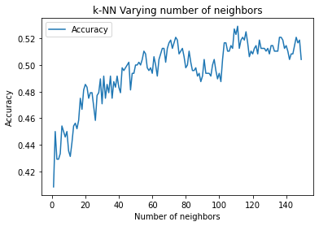

```python
#Using a grid search on actual test data, let's find best k value

#Setup arrays to store training and test accuracies
neighbors = np.arange(1,150)
accuracy = np.empty(len(neighbors))

for i,k in enumerate(neighbors):
    #Setup a knn classifier with k neighbors
    knn = KNeighborsClassifier(n_neighbors=k)

    #Fit the model
    knn.fit(red_X_train, red_Y_train)

    #Compute accuracy
    red_Y_pred = knn.predict(red_X_test)
    accuracy[i] = metrics.accuracy_score(red_Y_test,red_Y_pred)


#Generate plot
plt.title('k-NN Varying number of neighbors')
plt.plot(neighbors, accuracy, label='Accuracy')
plt.legend()
plt.xlabel('Number of neighbors')
plt.ylabel('Accuracy')
plt.show()
```

```python
knn = KNeighborsClassifier(n_neighbors=2)
knn.fit(red_X_train, red_Y_train)
print("Train accuracy "+str(knn.score(red_X_train, red_Y_train)))
print("Test accuracy "+str(knn.score(red_X_test, red_Y_test)))
```

```
Train accuracy 0.80875781948168
Test accuracy 0.45
```

```python
#Accuracy is not great. Let's try some other methods to look at model performance
```

```python
#I initially split the training/test data via 'holdout' data.
#I'd like to see if implementing a 5-fold cross validation can give a better idea of the model's performance capability

#https://scikit-learn.org/stable/modules/generated/sklearn.model_selection.cross_val_score.html

from sklearn.model_selection import cross_val_score

#Judging by the above plot, 115 neighbors seems to be optimal for this dataset
knn_cross_val = KNeighborsClassifier(n_neighbors=115)

#set cross validation at 5 folds
cross_val_scores = cross_val_score(knn_cross_val, red_X_train, red_Y_train, cv=5)

#the result will be the accuracy across 5 folds
print(cross_val_scores)
```

```
[0.44196429 0.55803571 0.44642857 0.51785714 0.41704036]
```

```python
#We see a 55% accuracy across 1 fold, a 5 point increase.
#I'd like to use GridSearchCV to perform a grid search including cross validation

#https://scikit-learn.org/stable/modules/generated/sklearn.model_selection.GridSearchCV.html

from sklearn.model_selection import GridSearchCV

knn = KNeighborsClassifier()
#Grid Search takes a dict of n_neighbors as a parameter
param_grid = {'n_neighbors': np.arange(1, 150)}
knn_grid_search = GridSearchCV(knn, param_grid, cv=5)
knn_grid_search.fit(red_X_train, red_Y_train)
```

```
GridSearchCV(cv=5, estimator=KNeighborsClassifier(),
             param_grid={'n_neighbors': array([  1,   2,   3,   4,   5,   6,   7,   8,   9,  10,  11,  12,  13,
        14,  15,  16,  17,  18,  19,  20,  21,  22,  23,  24,  25,  26,
        27,  28,  29,  30,  31,  32,  33,  34,  35,  36,  37,  38,  39,
        40,  41,  42,  43,  44,  45,  46,  47,  48,  49,  50,  51,  52,
        53,  54,  55,  56,  57,  58,  59,  60,  61,  62,  63,  64,  65,
        66,  67,  68,  69,  70,  71,  72,  73,  74,  75,  76,  77,  78,
        79,  80,  81,  82,  83,  84,  85,  86,  87,  88,  89,  90,  91,
        92,  93,  94,  95,  96,  97,  98,  99, 100, 101, 102, 103, 104,
       105, 106, 107, 108, 109, 110, 111, 112, 113, 114, 115, 116, 117,
       118, 119, 120, 121, 122, 123, 124, 125, 126, 127, 128, 129, 130,
       131, 132, 133, 134, 135, 136, 137, 138, 139, 140, 141, 142, 143,
       144, 145, 146, 147, 148, 149])})
```

```python
knn_grid_search.best_params_
knn_grid_search.best_score_
```

```
0.515622998078155
```

```python
#51%... Still not great
```

# Tuning

```python
#I'm going to try a few different tuning strategies to imporove performance
```

```python
#First, I'm going to create new, more simple labels which will be based on the qualities of the wines
#Instead of 1-10 quality as labels, I am consolidating into 4 labels: poor, fair, good, excellent
rating = []
for quality in red_wine_df["quality"]:
    if quality<4:
        rating.append("Poor")
    elif quality>7:
        rating.append("Excellent")
    elif quality in range(4,6):
        rating.append("Fair")
    else:
        rating.append("Good")

#add new column to df
red_wine_df['rating'] = rating

#delete numeric quality rating (old labels)
del red_wine_df['quality']

#new features
red_features = red_wine_df.drop('rating', axis=1)

#create var for labels
red_labels = red_wine_df["rating"]

#Split data up 70|30 for train|test respectively
red_Y_train = red_labels[0:1119]
red_X_train = red_features[0:1119]

red_Y_test = red_labels[1119:]
red_X_test = red_features[1119:]
```

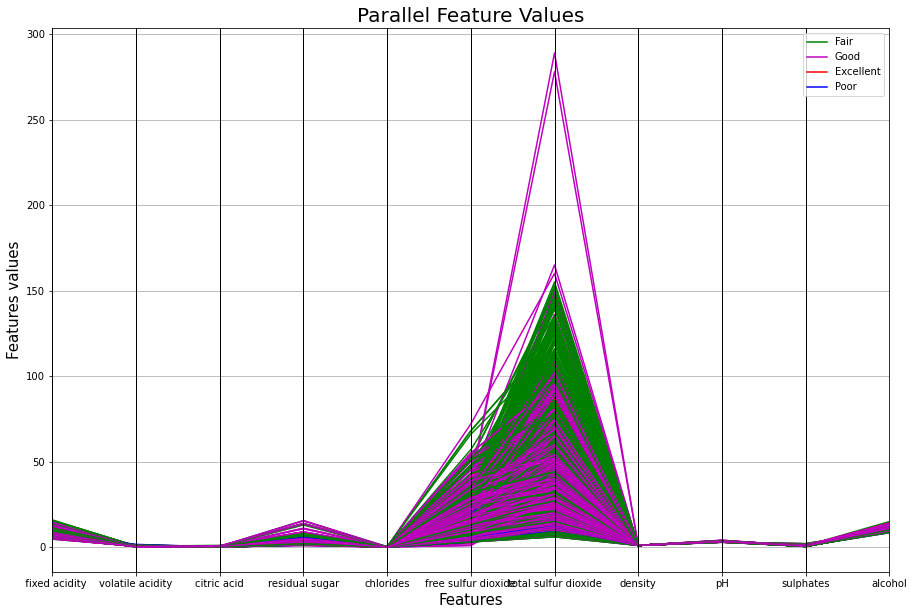

```python
#knn can have issues with scaling across features.
#Let's inspect the feature values, to see if specific features could be affecting accuracy

from pandas.plotting import parallel_coordinates
plt.figure(figsize=(15,10))
parallel_coordinates(red_wine_df, "rating",color=['g','m','r','b'])
plt.title('Parallel Feature Values', fontsize=20)
plt.xlabel('Features', fontsize=15)
plt.ylabel('Features values', fontsize=15)
plt.show()
```

```python
#The 2 features measuring for sulfur are far, far larger than the rest of the dataset
#I suspect that the difference in scaling is affecting performance
#I'm going to remove these features

red_features = red_features.drop('free sulfur dioxide', axis=1)
red_features = red_features.drop('total sulfur dioxide', axis=1)


#create var for new labels
red_X_train = red_features[0:1119]
red_X_test = red_features[1119:]
```

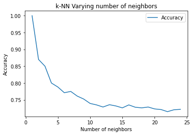

```python
#Setup arrays to store training and test accuracies
neighbors = np.arange(1,25)
accuracy = np.empty(len(neighbors))

for i,k in enumerate(neighbors):
    #Setup a knn classifier with k neighbors
    knn = KNeighborsClassifier(n_neighbors=k)

    #Fit the model
    knn.fit(red_features, red_labels)

    #Compute accuracy
    accuracy[i] = knn.score(red_features, red_labels)

#Generate plot
plt.title('k-NN Varying number of neighbors')
plt.plot(neighbors, accuracy, label='Accuracy')
plt.legend()
plt.xlabel('Number of neighbors')
plt.ylabel('Accuracy')
plt.show()
```

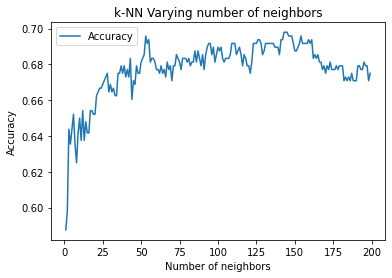

```python
neighbors = np.arange(1,200)
accuracy = np.empty(len(neighbors))

for i,k in enumerate(neighbors):
    #Setup a knn classifier with k neighbors
    knn = KNeighborsClassifier(n_neighbors=k)

    #Fit the model
    knn.fit(red_X_train, red_Y_train)

    #Compute accuracy
    red_Y_pred = knn.predict(red_X_test)
    accuracy[i] = metrics.accuracy_score(red_Y_test,red_Y_pred)
    #print(accuracy[i],k)


#Generate plot
plt.title('k-NN Varying number of neighbors')
plt.plot(neighbors, accuracy, label='Accuracy')
plt.legend()
plt.xlabel('Number of neighbors')
plt.ylabel('Accuracy')
plt.show()
```

```python
#Judging by the above plot, 145 neighbors seems to be optimal
knn_cross_val = KNeighborsClassifier(n_neighbors=145)

#set cross validation at 5
cross_val_scores = cross_val_score(knn_cross_val, red_X_train, red_Y_train, cv=5)

#the result will be the accuracy across 5 folds
print(cross_val_scores)
```

```
[0.58482143 0.73214286 0.61607143 0.77232143 0.72197309]
```

```python
from sklearn.model_selection import GridSearchCV

#
knn = KNeighborsClassifier()
#Grid Search takes a dict of n_neighbors as a parameter
param_grid = {'n_neighbors': np.arange(1, 150)}
knn_grid_search = GridSearchCV(knn, param_grid, cv=5)
knn_grid_search.fit(red_X_train, red_Y_train)
```

```
GridSearchCV(cv=5, estimator=KNeighborsClassifier(),
             param_grid={'n_neighbors': array([  1,   2,   3,   4,   5,   6,   7,   8,   9,  10,  11,  12,  13,
        14,  15,  16,  17,  18,  19,  20,  21,  22,  23,  24,  25,  26,
        27,  28,  29,  30,  31,  32,  33,  34,  35,  36,  37,  38,  39,
        40,  41,  42,  43,  44,  45,  46,  47,  48,  49,  50,  51,  52,
        53,  54,  55,  56,  57,  58,  59,  60,  61,  62,  63,  64,  65,
        66,  67,  68,  69,  70,  71,  72,  73,  74,  75,  76,  77,  78,
        79,  80,  81,  82,  83,  84,  85,  86,  87,  88,  89,  90,  91,
        92,  93,  94,  95,  96,  97,  98,  99, 100, 101, 102, 103, 104,
       105, 106, 107, 108, 109, 110, 111, 112, 113, 114, 115, 116, 117,
       118, 119, 120, 121, 122, 123, 124, 125, 126, 127, 128, 129, 130,
       131, 132, 133, 134, 135, 136, 137, 138, 139, 140, 141, 142, 143,
       144, 145, 146, 147, 148, 149])})
```

```python
knn_grid_search.best_params_
knn_grid_search.best_score_
```

```
0.6926049007046765
```

```python
knn = KNeighborsClassifier(n_neighbors=145)
knn.fit(red_X_train, red_Y_train)
print("Train accuracy "+str(knn.score(red_X_train, red_Y_train)))
print("Test accuracy "+str(knn.score(red_X_test, red_Y_test)))
```

```
Train accuracy 0.7059874888293118
Test accuracy 0.6979166666666666
```

We see close to a 20 point increase in model accuracy by doing 2 things:

1. simplifying/consolidating labels
2. removing features that are poorly scaled to the rest of the features

[output not shown]

## Results

*Using this cell, please write a short, clear paragraph explaining your results. In this class, we have mostly focused on accuracy. It is OK to measure your results in another quantitative way (e.g. precision or likelihood). Whatever you pick, make sure you are clear on what you are doing, and make sure you explain why your measurement of success makes sense.*

When properly tuned and by removing features that do not scale well with the rest of the features, knn can predict a wine's 'quality' (a subjective score given by humans) based off its chemical composition with 70% accuracy. Not bad! Plots demostrating this are above.

## Error analysis

I'm confused as to why precision and recall is 0 for Excellent and Poor labels. Precision AND Recall of 0 would mean that the classifier found no true positives? There are definitely wines in the dataset with those labels, so I'm not entirely sure what's going on there. If I had to guess, perhaps it is because the are so little wines that have those labels compared to the other labels.

```python
from sklearn.metrics import classification_report
#https://scikit-learn.org/stable/modules/generated/sklearn.metrics.classification_report.html

pred_knn=knn.predict(red_X_test)
print(classification_report(red_Y_test, pred_knn))
```

```
              precision    recall  f1-score   support

   Excellent       0.00      0.00      0.00         6
        Fair       0.65      0.72      0.68       209
        Good       0.74      0.71      0.72       260
        Poor       0.00      0.00      0.00         5

    accuracy                           0.70       480
   macro avg       0.35      0.36      0.35       480
weighted avg       0.69      0.70      0.69       480
```

```python
red_labels.value_counts()
```

```
Good         837
Fair         734
Excellent     18
Poor          10
Name: rating, dtype: int64
```

## Discussion

*Using this cell, please write a short, clear paragraph describing how your results answer or do not answer your question. What new questions arise from your work?*

I wanted to see if a classifier could identify a wine's 'quality' (a subjective score given by humans) based off its chemical composition. Knn was able to predict a wine's quality with 70% accuracy. I chose knn because I believed wines with similar characteristics would have similar ratings, resulting in solid clusters that knn would excel in classifying. For future work, I think it would be important to try out different algorithms to see if I could get higher testing accuracy. I think I would try out random forrest. Also, it would be very interesting to attempt to determine which characteristics were most correlated to accuractely predicting a high wine quality.